# HITO 1: Análisis clientes Block

María Hernández, Sebastián Moreno, Lung Pang, Cristóbal Saldías, Víctor Vidal.

28 de Septiembre 2021

# 1.Introducción

**Blockstore** es una cadena de tiendas, ubicada en Chile, enfocada la venta de zapatillas, accesorios y vestuario de las mejores marcas urbanas. Dada la contingencia mundial de la pandemia y el estallido social del 2019, Block tuvo que adaptarse al canal de ventas online por lo que la necesidad de la aplicación de análisis de datos y en particular de minería de datos va en el contexto cambiante en el ámbito nacional, donde la crisis social, pandemia, mayor dinero circulante y un aumento explosivo en ventas online hacen necesario tener las mejores estrategias diferenciadas para cada cliente,

Es por esto que decidimos estudiar el comportamiento de compra de los clientes a nivel nacional. Nos parece interesante estudiar estos datos para generar más ventas enfocando una estrategia de negocios diferenciada para cada grupo de clientes en específico de acuerdo a sus gustos.

# 2.Exploración de Datos

```r
# Asignamos nuestro "working directory" (set w. d.) como el directorio ~/RDATA y ponemos librerías
setwd("C:/Users/Cherry/Desktop/U/Semestre-8/Mineria/Hito1/Data-Mining-CC5206/")
library(ggplot2)
library(dplyr)
```

**Cargamos los datos originales** Sin embargo, estos datos no están limpios debido a que los clientes no ingresaron bien los datos, por lo que se realizó una limpieza de los datos para poder trabajar de mejor manera.

```r
pedidos_preeliminar <- read.csv("orders.csv", encoding = "UTF-8")
pedidos_detalle_preeliminar <-read.csv("order_detail.csv", encoding = "UTF-8")
```

A modo de resumen se dejan la cantidad de columnas y filas de cada dataset

```r
nrow(pedidos_preeliminar)
```

```
## [1] 104955
```

```r
ncol(pedidos_preeliminar)
```

```
## [1] 68
```

```r
nrow(pedidos_detalle_preeliminar)
```

```
## [1] 126704
```

```r
ncol(pedidos_detalle_preeliminar)
```

```
## [1] 9
```

Para la limpieza se eliminaron filas vacías, datos *dummy* realizados por la empresa, y otros valores incosistentes y repetitivos. También se hizo un refactoring de los nombres de las columnas para un mejor entendimiento del dataset.

```r
pedidos<-read.csv("Orders_OFICIAL.csv", encoding = "UTF-8", sep=";")
pedidos_detalle <-read.csv("ORDER_DETAIL_OFICIAL.csv", encoding = "UTF-8",sep=";")
pedidos$count <- as.numeric(ave(pedidos$Comuna, pedidos$Comuna, FUN = length))
pedidos_detalle$count.marca <- as.numeric(ave(pedidos_detalle$Marca, pedidos_detalle$Marca, FUN = length))
```

```r
# Se cambia el formato de la columna Fecha.Compra a Date.
pedidos$Fecha.Compra <- as.Date(pedidos$Fecha.Compra, format ="%d-%m-%Y")
# Se cambia el formato de la columna Fecha.Pedido a Date. También se agrega una columna con el año.
pedidos_detalle$Fecha.Pedido <- as.Date(pedidos_detalle$Fecha.Pedido, format ="%Y-%m-%d")
pedidos_detalle$anio <- as.numeric(format(pedidos_detalle$Fecha.Pedido,'%Y'))
```

# 2.1. Estudio sobre los datos filtrados

1. **A grandes razgos podemos calcular la cantidad promedio que se gasta una persona en Block:**

```r
nfilas <- nrow(pedidos)
total_vendido <- sum(pedidos$Precio.Pedido)
promedio_pedidos <- total_vendido/nfilas
(promedio_pedidos)
```

```
## [1] 45364.45
```

```r
#La gente que pide mas que el promedio
pedidos_RM_mayorpromedio <- data.frame(pedidos[pedidos$REGION.CON.CODIGO == "RM" & pedidos$Precio.Pedido > promedio_pedidos,] )
nrow(pedidos_RM_mayorpromedio)
```

```
## [1] 36083
```

```r
#La gente que pide menos que el promedio
pedidos_RM_menorpromedio <- data.frame(pedidos[pedidos$REGION.CON.CODIGO == "RM" & pedidos$Precio.Pedido <= promedio_pedidos,] )
nrow(pedidos_RM_menorpromedio)
```

```
## [1] 45759
```

3. **El pedido más caro en Block online** Podemos ver que en la tabla pedidos_Detalles según el numero de pedido podemos ver el detalle de la compra que realizó la clienta.

```r
pedidos[which.max(pedidos$Precio.Pedido),]
```

```
##      X.U.FEFF.ID                    Email Precio.Pedido Numero.Pedido
## 3488    1,72E+12 alfredo.e.vega@gmail.com        454116       #BL4499
##        ID.Cliente Fecha.Compra Año.Compra Mes.Compra Cantidad.Pedidos.Cliente
## 3488 1.939678e+12   2019-07-25       2019          7                       17
##      Total.Gastado.Cliente       RUT           Direccion.1 Direccion.2 Comuna
## 3488               1050781 18172868k Caupolican 1620 renca         210  RENCA
##      Nombre.Cliente REGION.CON.CODIGO Tipo.despacho count
## 3488 Camila Fuentes                RM      Despacho  1337
```

```r
#usamos su numero de pedido para ver las compras realizadas
pedido_maximo_detalle <- pedidos_detalle[pedidos_detalle$Numero.Pedido == "#BL4499",]
#verificamos el dinero sea consistente en ambas tablas
sum(pedido_maximo_detalle$Precio.Total.Productos)
```

```
## [1] 454116
```

4. **La cantidad de pedidos divididos por región:**

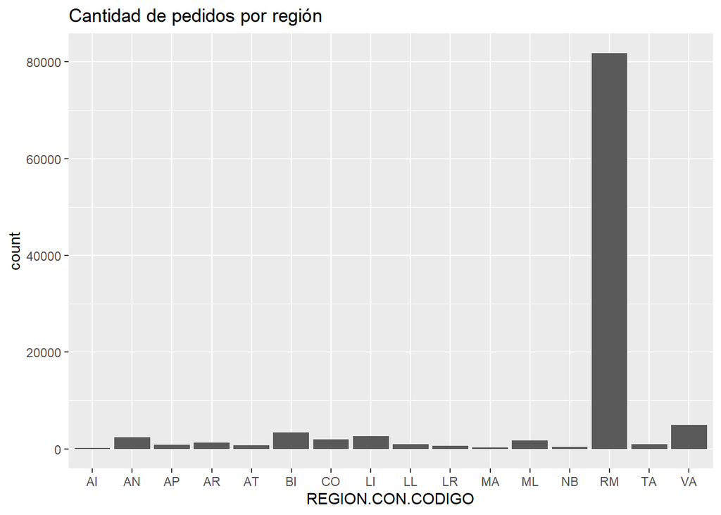

```r
ggplot(pedidos, aes(x = REGION.CON.CODIGO),) +
   ggtitle("Cantidad de pedidos por región") +
  geom_bar()
```

5. **Cantidad de pedidos dividos por comuna**

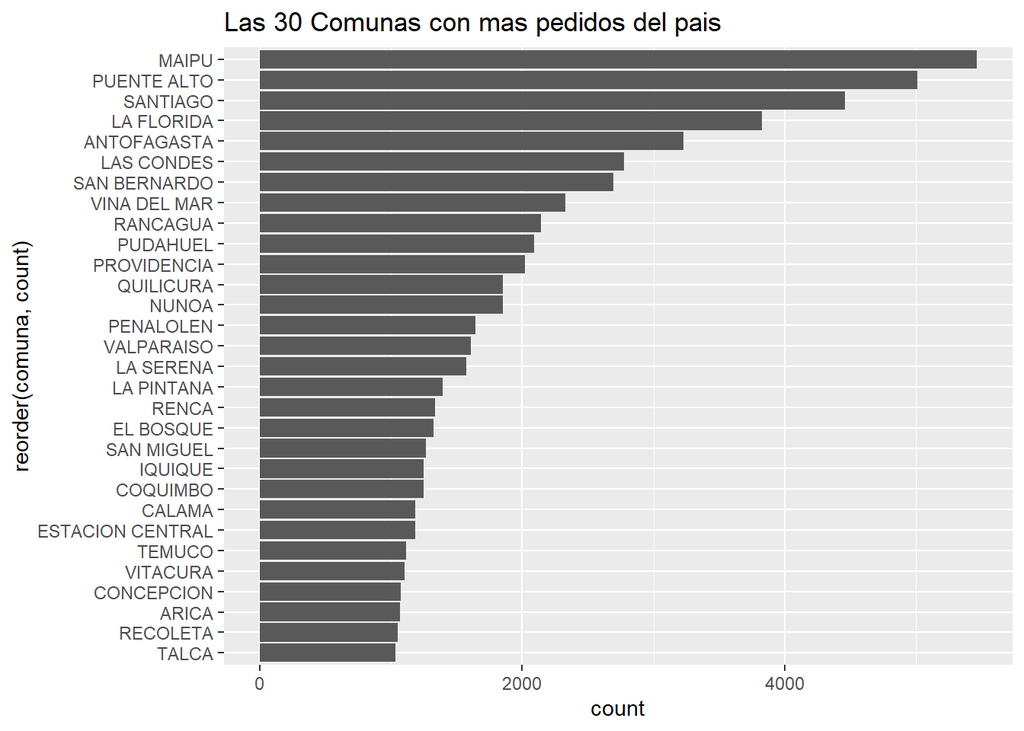

```r
freq_comuna <- data.frame(comuna = pedidos$Comuna, count = pedidos$count)
freq_comuna <-  unique(freq_comuna)
freq_comuna <- freq_comuna[order(freq_comuna[,"count"], decreasing = TRUE),]
ggplot(freq_comuna[1:30,], aes(x = reorder(comuna , count),y = count)) + ggtitle("Las 30 Comunas con mas pedidos del pais") + coord_flip() + geom_bar(stat = "identity")
```

```r
pedidos_comuna_Lascondes <- data.frame(pedidos[pedidos$Comuna == "LAS CONDES", ] )
nrow(pedidos_comuna_Lascondes)
```

```
## [1] 2777
```

```r
mean(pedidos_comuna_Lascondes$Precio.Pedido)
```

```
## [1] 47841.46
```

```r
sum(pedidos_comuna_Lascondes$Precio.Pedido)
```

```
## [1] 132855726
```

```r
pedidos_comuna_maipu <- data.frame(pedidos[pedidos$Comuna == "MAIPU", ] )
nrow(pedidos_comuna_maipu)
```

```
## [1] 5462
```

```r
mean(pedidos_comuna_maipu$Precio.Pedido)
```

```
## [1] 42816.93
```

```r
sum(pedidos_comuna_maipu$Precio.Pedido)
```

```
## [1] 233866080
```

7. **Se deja un historial de pedidos desde el inicio del dataset hasta la ultima fecha presente:**

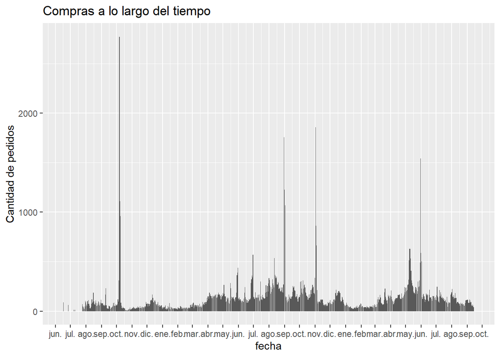

```r
ggplot(pedidos, aes(x = Fecha.Compra) ) + geom_bar() + scale_x_date(date_breaks = "1 month", date_labels = "%b") + labs(title = "Compras a lo largo del tiempo", x = "fecha", y = "Cantidad de pedidos")
```

8. **Vamos a ver cuanto se ha vendido en block por marca**

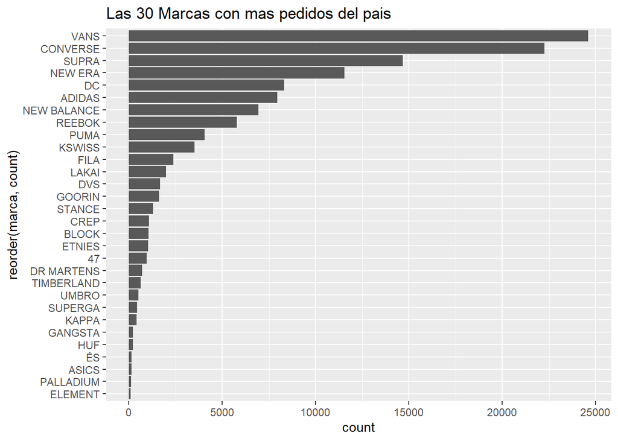

```r
freq_marca <- data.frame(marca = pedidos_detalle$Marca, count = pedidos_detalle$count.marca)
freq_marca <-  unique(freq_marca)
freq_marca <- freq_marca[order(freq_marca[,"count"], decreasing = TRUE),]

ggplot(freq_marca[1:30,], aes(x = reorder(marca , count), y = count)) + ggtitle("Las 30 Marcas con mas pedidos del pais") + coord_flip() + geom_bar(stat = "identity")
```

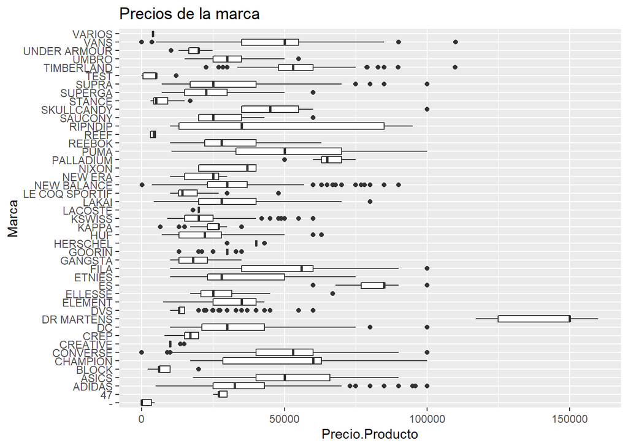

```r
precio_marca <- data.frame(marca = pedidos_detalle$Marca, precio = pedidos_detalle$Precio.Producto)

p1 <- ggplot(pedidos_detalle, aes(x = Marca, y = Precio.Producto)) + geom_boxplot()+ coord_flip() + ggtitle("Precios de la marca")
p1
```

```r
ggsave(p1, filename = "C:/Users/Cherry/Desktop/U/Semestre-8/Mineria/Hito1/Data-Mining-CC5206test.png",height = 10, width = 10)
```

# Preguntas y problemas

Dada la exploración anterior y su motivación original, formular preguntas que se pueden responder mediante la minería de datos y que se puedan vincular a la problemática planteada en la motivación

1. **¿Cómo se relaciona el precio de la compra con el lugar desde donde se pidió? (En las regiones piden paquetes más caros?)**
2. **¿Qué marcas se compran más según el sector?**
3. **¿Qué productos se compran juntos?**
4. **¿Existe una tendencia en la segunda compra con respecto a la primera?(se compra la misma marca 2 veces?)**
5. **¿Qué producto puede que compre alguien que ya adquirió x producto?**

# Contribuciones

**María Hernández:** Encargada de encontrar el dataset.

**Sebastián Moreno:** Encargado de la limpieza de datos.

**Lung Pang:** Encargado de hacer el repositorio de GitHub y gráficos.

**Cristóbal Saldías** Encargado del informe y su organización.

**Víctor Vidal** Encargado de hacer la presentación.